# Esports Earnings 1998 - 2021

# Installing Packages

```r
install.packages("tidyverse")
install.packages("readr")
```

# Calling the Packages Library

```r
library(tidyverse)
library(readr)
```

# Importing the Data set of Esports Earnings

```r
Esports <- read.csv("GeneralEsportData.csv")

Esports
```

| Game | ReleaseDate | Genre | TotalEarnings | OnlineEarnings | TotalPlayers | TotalTournaments |
| --- | --- | --- | --- | --- | --- | --- |
| Age of Empires | 1997 | Strategy | 191181.81 | 156839.89 | 261 | 99 |
| Age of Empires II | 1999 | Strategy | 2280004.90 | 720999.87 | 1508 | 1107 |
| Age of Empires III | 2005 | Strategy | 93913.65 | 41800.00 | 139 | 120 |
| Age of Empires IV | 2021 | Strategy | 75765.25 | 217.00 | 115 | 56 |
| Age of Empires Online | 2011 | Strategy | 5283.56 | 775.00 | 22 | 16 |
| Age of Mythology | 2002 | Strategy | 100551.00 | 52000.00 | 129 | 121 |
| Among Us | 2018 | Strategy | 86000.00 | 0.00 | 14 | 8 |
| Auto Chess | 2019 | Strategy | 1143720.28 | 1037122.28 | 123 | 36 |
| Brawl Stars | 2018 | Strategy | 2557950.00 | 1336250.00 | 215 | 31 |
| Chess.com | 2007 | Strategy | 1826564.33 | 0.00 | 771 | 272 |

[output cut: 542 more lines]

# Fig 1: Histogram

## The Data set will be filter to feature only the Release Dates between 1998-2005.

```r
# The Data set will be filter to feature only the Release Dates greater than or equal to 1998 and less than or equal to 2005

dataFilter <- filter(Esports, ReleaseDate >= 1998 & ReleaseDate <= 2005)

dataFilter
```

| Game | ReleaseDate | Genre | TotalEarnings | OnlineEarnings | TotalPlayers | TotalTournaments |
| --- | --- | --- | --- | --- | --- | --- |
| Age of Empires II | 1999 | Strategy | 2280004.90 | 720999.87 | 1508 | 1107 |
| Age of Empires III | 2005 | Strategy | 93913.65 | 41800.00 | 139 | 120 |
| Age of Mythology | 2002 | Strategy | 100551.00 | 52000.00 | 129 | 121 |
| Heroes of Might and Magic III | 1999 | Strategy | 0.00 | 0.00 | 0 | 0 |
| Multigaming | 2000 | Strategy | 444857.33 | 444857.33 | 30 | 7 |
| Playchess.com | 2002 | Strategy | 32866.58 | 0.00 | 116 | 9 |
| StarCraft: Brood War | 1998 | Strategy | 8595085.61 | 8159939.32 | 685 | 686 |
| WarCraft III | 2002 | Strategy | 5811479.73 | 5038870.86 | 558 | 1335 |
| Warhammer 40,000: Dawn of War | 2005 | Strategy | 79816.50 | 79816.50 | 7 | 3 |
| Aliens versus Predator 2 | 2001 | First-Person Shooter | 40000.00 | 40000.00 | 1 | 1 |

[output cut: 91 more lines]

## After filtering the data, it will than be process for selection to specified specific columns like (Release Date, Total Tournaments, and Genre).

```r
# The data after filtering will than be process for selection of specific columns of (Release Date, Total Tournaments, and Genre).

histoGraph <- select(dataFilter,ReleaseDate, TotalTournaments, Genre)

histoGraph
```

| ReleaseDate | TotalTournaments | Genre |
| --- | --- | --- |
| 1999 | 1107 | Strategy |
| 2005 | 120 | Strategy |
| 2002 | 121 | Strategy |
| 1999 | 0 | Strategy |
| 2000 | 7 | Strategy |
| 2002 | 9 | Strategy |
| 1998 | 686 | Strategy |
| 2002 | 1335 | Strategy |
| 2005 | 3 | Strategy |
| 2001 | 1 | First-Person Shooter |

[output cut: 91 more lines]

## Then labels were given to the graph to help the viewer understand what is going on.

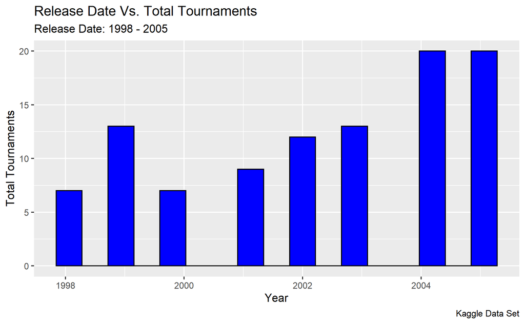

```r
# Finally, the final process will than be used to create our Histogram of total tournaments withing an 8 year period while being fill with a specific fill color and outer color column.

# Then labels were given to the graph to help the viewer understand what is going on.

ggplot(data = histoGraph) + geom_histogram(mapping = aes(x = ReleaseDate), fill = "blue", color = "black", bins = 17) + labs(title = "Release Date Vs. Total Tournaments", subtitle = "Release Date: 1998 - 2005", x = "Year", y = "Total Tournaments", caption = "Kaggle Data Set")
```

# Fig 2: Violin Plot

## While using the same filter as before with the same selection coulnms we will than build our violin plot.

```r
# The data after filtering will than be process for selection of specific columns of (Release Date, Total Tournaments, and Genre).

violinPlot <- select(dataFilter,ReleaseDate, TotalTournaments, Genre)

violinPlot
```

| ReleaseDate | TotalTournaments | Genre |
| --- | --- | --- |
| 1999 | 1107 | Strategy |
| 2005 | 120 | Strategy |
| 2002 | 121 | Strategy |
| 1999 | 0 | Strategy |
| 2000 | 7 | Strategy |
| 2002 | 9 | Strategy |
| 1998 | 686 | Strategy |
| 2002 | 1335 | Strategy |
| 2005 | 3 | Strategy |
| 2001 | 1 | First-Person Shooter |

[output cut: 91 more lines]

## Finally, the final process will than be used to create our violin plot of total tournaments withing an 8 year period while being fill with a specific fill color and outer color column.

## Then labels were given to the graph to help the viewer understand what is going on.

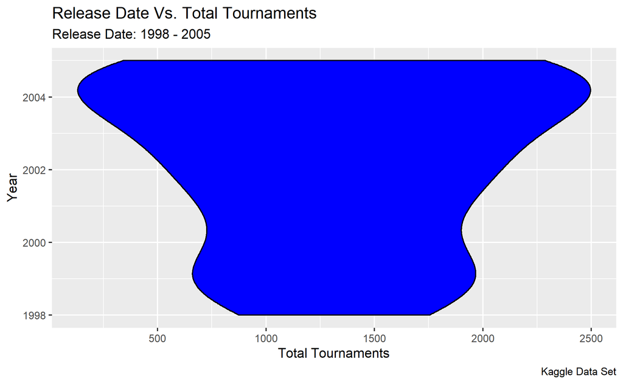

```r
# Finally, the final process will than be used to create our violin plot of total tournaments withing an 8 year period while being fill with a specific fill color and outer color column.

# Then labels were given to the graph to help the viewer understand what is going on.

ggplot(data = violinPlot, mapping = aes(x = TotalTournaments , y = ReleaseDate)) + geom_violin(fill = "blue", color = "black")+ labs(title = "Release Date Vs. Total Tournaments", subtitle = "Release Date: 1998 - 2005", y = "Year", x = "Total Tournaments", caption = "Kaggle Data Set")
```

# Fig 3: Box plot

## While using the same filter as before with the same selection coulnms we will than build our box plot.

```r
# The data after filtering will than be process for selection of specific columns of (Release Date, Total Tournaments, and Genre).

boxPlot <- select(dataFilter,ReleaseDate, TotalTournaments, Genre)

boxPlot
```

| ReleaseDate | TotalTournaments | Genre |
| --- | --- | --- |
| 1999 | 1107 | Strategy |
| 2005 | 120 | Strategy |
| 2002 | 121 | Strategy |
| 1999 | 0 | Strategy |
| 2000 | 7 | Strategy |
| 2002 | 9 | Strategy |
| 1998 | 686 | Strategy |
| 2002 | 1335 | Strategy |
| 2005 | 3 | Strategy |
| 2001 | 1 | First-Person Shooter |

[output cut: 91 more lines]

## Finally, the final process will than be used to create our box plot of total tournaments withing an 8 year period while being fill with the colunm Genre to specified which box plot.

## Then labels were given to the graph to help the viewer understand what is going on.

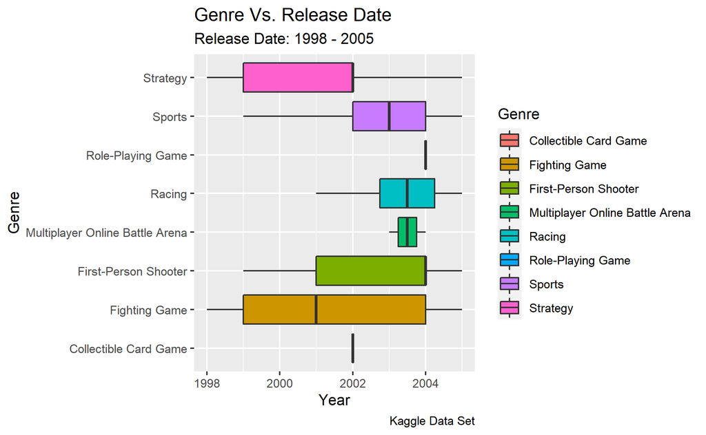

```r
ggplot(data = boxPlot, mapping = aes(x =ReleaseDate, y = Genre, fill = Genre)) + geom_boxplot()+ labs(title = "Genre Vs. Release Date", subtitle = "Release Date: 1998 - 2005", x = "Year", y = "Genre", caption = "Kaggle Data Set")
```

Follow up: A box plot is a data visualization that uses box and several lines to depict data distribution of a data set. They are super helpful for depicting distributions of multiple things at once, depending on how you set up your data set. Nonetheless, with the plot above, it shows a distributions of game genres that are used most throughout the years of 1998-2005. Three genres stand out from the plot fighting Game, First-person shooting and Strategy. However, the genre that stretches out the most throughout many years is Fighting Games (1999-2004).